# Split and Merge Segmentation

**Image segmentation: Split and Merge algorithm**

**Objective:** Implement Python application for image segmentation using the algorithm Split and Merge in order to attempt to divide an image into uniform regions.

**Brief description:** Split-merge algorithm is a general approach for image segmentation based on region growing. Using this algoritm we try to divide the image into uniform regions. The image is continuously divided into quadrants based on homogeneity criteria and similar regions are merged to create segmented results.

Importam urmatoarele librarii specifice Python:

- OpenCV (Open Source Computer Vision Library) - procesarea imaginilor si analiza video;
- Math - operatii matematice avansate;
- NumPy - calcul numeric;
- Matplotlib - vizualizare grafica si afisare imagini;
- Google Colab - incarcare si afisare imagini in Colab.

```python
import cv2
import math
import numpy as np
import matplotlib.pyplot as plt
from google.colab import files
from google.colab.patches import cv2_imshow
```

Incarcam si citim imaginea dorita.  
Verificam daca imaginea a fost incarcata corect. In caz afirmativ, afisam imaginea.

Upload widget is only available when the cell has been executed in the current browser session. Please rerun this cell to enable.

```
Saving PageMillRoad.png to PageMillRoad.png
Imaginea a fost incarcata cu succes.
```

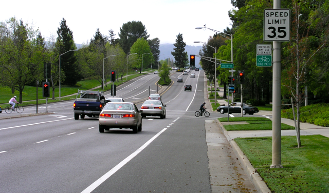

```python
uploaded = files.upload()
imgFileName = list(uploaded.keys())[0]
image = cv2.imread(imgFileName)

if image is None:
  print("Eroare la incarcarea imaginii.")
else:
  print("Imaginea a fost incarcata cu succes.")
  cv2_imshow(image)
```

# Split Function

Vom imparti imaginea recursiv in blocuri mai mici pe baza criteriului de omogenitate a culorilor. In fiecare bloc calculam media si deviatia standard a culorii. Daca deviatia standard depaseste un anumit prag (threshold) blocul este impartit in patru sub-blocuri, iar procesul se repeta recursiv pentru fiecare sub-bloc. Daca deviatia standard este mai mica decat pragul si blocul este suficient de mic, inseamna ca regiunea este omogena, iar aceasta este adaugata in lista de regiuni (regions). Dupa ce toate sub-regiunile sunt procesate, fiecare regiune omogena este reprezentata de un dreptunghi umplut cu culoarea medie a acelei regiuni.

```python
# Functia recursiva pentru Split pentru toate canalele de culori
def split(image, x, y, width, height, threshold, regions=None):
  # Initializam lista de regiuni
  if regions is None:
        regions = []

  # Selectam regiunea curenta
  region = image[y:y+height, x:x+width]

  # Calculam Media si Devianta Standard a culorii
  mean, stddev = cv2.meanStdDev(region)

  # Verificam daca Devianta Standard este mai mare decat threshold-ul, pentru cel putin un canal
  if any(stddev_channel > threshold for stddev_channel in stddev[:, 0]) and width > 1 and height > 1:
    half_w, half_h = width // 2, height // 2
    # Impartim regiunea in 4 parti pe care le vom procesa recursiv
    split(image, x, y, half_w, half_h, threshold, regions)
    split(image, x + half_w, y, half_w, half_h, threshold, regions)
    split(image, x, y + half_h, half_w, half_h, threshold, regions)
    split(image, x + half_w, y + half_h, half_w, half_h, threshold, regions)
  else:
    # Adaugam regiunea in lista 'regions' pentru etapa ulterioara de Merge
    regions.append((x, y, width, height, (int(mean[0][0]), int(mean[1][0]), int(mean[2][0]))))

  # Verificam daca am ajuns la finalul procesului split (regiunea curenta este intreaga imagine)
  if x == 0 and y == 0 and width == image.shape[1] and height == image.shape[0]:
    split_image = image.copy()
    for x, y, width, height, color in regions:
      # Desenam dreptunghiuri umplute cu media culorii regiunii respective pe toate canalele (BGR)
      cv2.rectangle(split_image, (x, y), (x + width, y + height), color, -1)
    return split_image
```

Setam threshold-ul pentru Split. Un prag mai mare va produce regiuni mai mari, iar un prag mai mic va rezulta o segmentare mai detaliata, cu mai multe regiuni.

```python
threshold = 30
split_image = split(image, 0, 0, image.shape[1], image.shape[0], threshold)
```

Salvam si afisam imaginea obtinuta in urma aplicarii algoritmului Split.

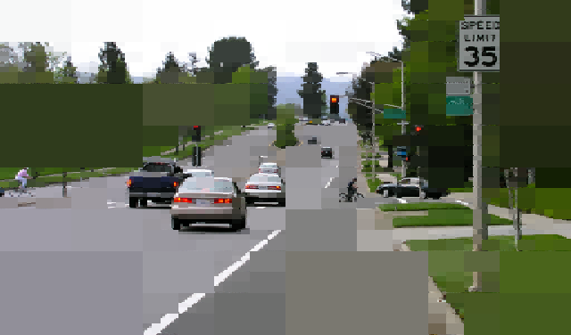

```python
cv2.imwrite("imagine_split.jpg", split_image)
cv2_imshow(split_image)
```

# Merge Function

Procesam imaginea impartita de algoritmul Split si combinam regiunile omogene de culoare care sunt suficient de apropiate intre ele. Inlocuim fiecare regiune cu o culoare medie a pixelileor din acea regiune.

```python
# Functia pentru Merge
def merge(image, merge_threshold):
    # Array 3D de dimensiuni (height, width, channels)
    height, width, _ = image.shape
    # Cream o matrice booleana fara canale pentru a urmari daca un pixel a fost procesat sau nu
    visited = np.zeros((height, width), dtype=bool)
    result = image.copy()

    # Functie pentru a calcula distana intre doua culori (BGR)
    def color_distance(color1, color2):
        # zip(color1, color2) combina fiecare componenta de culoare (r1, r2), (g1, g2), (b1, b2)
        return math.sqrt(sum((int(c1) - int(c2)) ** 2 for c1, c2 in zip(color1, color2)))

    # Functie recursiva pentru a extinde o regiune
    def grow_region(x, y, initial_color, current_region):
        stack = [(x, y)] # stiva Last In, First Out
        while stack:
            cx, cy = stack.pop() # extrage ultimul element
            # Verificam daca pixelul se afla in limitele imaginii si ca nu a fost deja vizitat
            if 0 <= cx < width and 0 <= cy < height and not visited[cy, cx]:
                current_color = result[cy, cx] # extragem culoarea pixelulu
                # Verificam distanta de culoare dintre pixelul curent si culoarea initiala a regiunii
                if color_distance(initial_color, current_color) < merge_threshold:
                    visited[cy, cx] = True
                    current_region.append((cx, cy))
                    # Adaugam vecinii pixelului curent in stiva pentru a fi procesati
                    stack.extend([(cx + 1, cy), (cx - 1, cy), (cx, cy + 1), (cx, cy - 1)])

    # Parcurgem fiecare pixel din imagine
    for y in range(height):
        for x in range(width):
            if not visited[y, x]:
                # Cream o lista goala pentru a stoca pixelii din regiunea curenta
                current_region = []
                initial_color = result[y, x] # salvam culoarea pixelului curent
                grow_region(x, y, initial_color, current_region)

                # Calculam noua culoare medie pentru regiunea curenta
                if current_region:
                    # Calculam media culorii tuturor pixelilor din regiune
                    avg_color = np.mean([result[cy, cx] for cx, cy in current_region], axis=0).astype(int)
                    # Actualizam fiecare pixel din regiune cu noua culoare medie
                    for cx, cy in current_region:
                        # Actualizam culoarea fiecarui pixel
                        result[cy, cx] = avg_color

    return result
```

Setam threshold-ul pentru Merge. Cu cat este mai mare cu atat regiunile vor fi mai mari si mai putin detaliate.

```python
merge_threshold = 60
merged_image = merge(split_image, merge_threshold)
```

Salvam si afisam imaginea obtinuta in urma aplicarii algoritmului Merge.

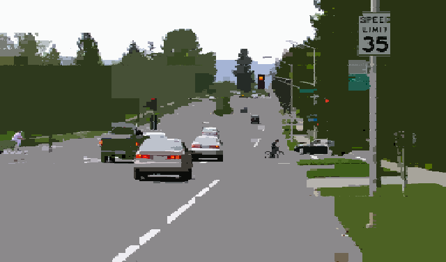

```python
cv2.imwrite("imagine_merge.jpg", merged_image)
cv2_imshow(merged_image)
```

# Resulting images

- Imaginea originala
- Imaginea dupa Split
- Imaginea dupa Merge

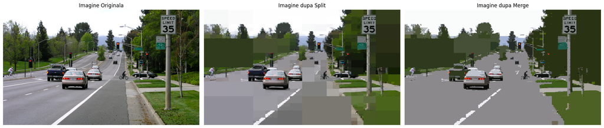

```python
# Citim imaginile pentru a le converti la format RGB pentru matplotlib
image_rgb = cv2.cvtColor(image, cv2.COLOR_BGR2RGB)
split_image_rgb = cv2.cvtColor(split_image, cv2.COLOR_BGR2RGB)
merged_image_rgb = cv2.cvtColor(merged_image, cv2.COLOR_BGR2RGB)

# Cream figura si axele pentru plot
fig, axes = plt.subplots(1, 3, figsize=(20, 10))  # 1 rand, 3 coloane

# Afisam imaginile
axes[0].imshow(image_rgb)
axes[0].axis('off')
axes[0].set_title("Imagine Originala")

axes[1].imshow(split_image_rgb)
axes[1].axis('off')
axes[1].set_title("Imagine dupa Split")

axes[2].imshow(merged_image_rgb)
axes[2].axis('off')
axes[2].set_title("Imagine dupa Merge")

plt.tight_layout()
plt.show()
```

Exportam proiectul in format html:

```python
from google.colab import drive
drive.mount('/content/drive')
```

```python
%%shell
jupyter nbconvert --to html '/content/drive/MyDrive/Colab Notebooks/Split_and_Merge_Segmentation.ipynb' --output='/content/Split_and_Merge_Segmentation.html'
```

```python
files.download('Split_and_Merge_Segmentation.html')
```